# STAT 201 - Statistical Inference for Data Science

## Mid-term 2 review

## Announcements/Reminders

- Solutions for most of worksheets and tutorials are available
- Please meet me if it shows 0 in the canvas grade book for homework/tutorial eventhough you completed before the due date
- **Group Project:** Instructions under "deliverable" on the course website
  - Final Report - December 7
  - Team Evaluation - December 7

## Announcements/Reminders

- **Midterm 2 - Wednesday, Nov 22** during the class time
  - covers material from modules 6 - 9(however, the content is cumulative as the concepts are dependent)
  - Closed book (but one-sided 8.5" by 11" cheat sheet/formula sheet is allowed to use in the exam. Cheat sheet can be handwritten or typed.)
  - will be served on Canvas (need to use the Lockdown Browser)
  - Will update information in the canvas course page this week
- **Final exam:**
  - Monnday, December 18
  - Will update information in the canvas page after the Midterm 2

## Course policy on plagiarism.

- If you violate academic integrity then there will be severe consequences including receiving 0 on the quiz (midterm exam) and will be reported to UBC Science.
- You can find more information on what happens if you violate academic integrity here: https://science.ubc.ca/students/blog/academic-integrity-what-is-cheating-consequencesLinks to an external site.
- In short, write the answer in your own words! Do not copy & paste from any sources.
- This also applies to worksheets/tutorials

## Midterm Quiz instructions

- Please mute your mobile devices, laptop
- If you have technical issues, please raise your hand
- We cannot answer any questions about the quiz itself, we can only support you with technical issues
- If you finish early, please stay in your seat until the end of the quiz

## Week 6 key concepts:

Hypothesis Testing via simulation/randomization

- Null and Alternative hypotheisis
- Test Statistic
- Rejection region
- p-value
- Significance level
- Type I and Type II errors
- Understanding statistically significant
- Hypothesis testing with the infer package

## Hypothesis testing with the `infer` package

[figure not shown]

*image source: [Modern Dive](https://moderndive.com) by Kim & McConville*

## Null Hypothesis

A hypothesis test is like an argument by contradiction.

[figure not shown]

## Null Hypothesis

A hypothesis test is like an argument by contradiction.

[figure not shown]

## Null Hypothesis

A hypothesis test is like an argument by contradiction.

[figure not shown]

## Week 7 key concepts:

Confidence Intervals (of means and proportions) based on the assumption of Normality or the Central Limit Theorem

- Normal (Gaussian) distribution
- 68-95-99.7% rule (Empirical rule)
- Normal distribution
- Central Limit Theorem
- Confidence Intervals:
  - means
  - proportions
  - Difference in means
  - Difference in proportions

## Week 8 key concepts:

Theory-based Hypothesis Tests. Classical Tests Based on Normal and t-Distributions

- Standardizing a variable
- Central Limit Theorem
- Null distribution
- $t$ - Distribution
- Bootstrapping vs. theory based approaches

## Week 9 key concepts:

Errors in Inference

- Decisions and Types of errors in Hypothesis Testing
- Understanding statistically significant
- Type I and Type II errors
- power of a test

## Deliverable 3: Final Report - Due on December 7

## Deliverable 4:Team Evaluation - Due on December 7

## Information

## Deliverable 2: Project Proposal

Each group is expected to prepare a written proposal within 500 words (excluding code) that identifies the dataset they plan to work on, as well as the question they would like to answer using that dataset for their group project. The proposal should be done in a Jupyter notebook, and then submitted both as an

- `.html` file (File → Download As → HTML) and
- `.ipynb` file that is reproducible (i.e. works and runs without any additional files).

Only one member of your team needs to submit.

Each proposal should include the following sections:

- Title
- Introduction
- Preliminary Results
- Methods: Plan
- References

# Group Project Owner Creates Repo with Template

- Template URL: https://github.com/UBC-DSCI/dsci-100-project_template
- Click on "Use this template"

[figure not shown]

- Why are we doing this?
  - We want to set up the `.gitignore` file so we limit the potential of conflicts
  - You only want to version control files that matter, not temporary and backup files
- The `.gitignore` file will "disapper" on jupyter lab, but you will see it in github

# Give the project a name

- This will be the same project name for everyone
- Just needs to be unique to your account

[figure not shown]

- The group project owner will then add everyone else as collaborators to the project
- See Collaboration chapter in textbook

## Data

- UCI Machine Learning Repository has hundreds of datasets
- City of Vancouver data: https://opendata.vancouver.ca/pages/home/ (or other cities, like Ottawa, Toronto, etc.)
- Vancouver crime data: https://geodash.vpd.ca/opendata/
- BC data: https://data.gov.bc.ca/
- Water survey of Canada: https://www.canada.ca/en/environment-climate-change/services/water-overview/quantity/monitoring/survey.html
- Climate and Weather Data: https://climate.weather.gc.ca/
- Sports data
- Maybe do your own experiment or observational study, if you have time – or maybe you already have the data. For example, do you track your daily step count? If so, you could come up with some criteria to determine whether you have been satisfying the goal, and use your daily step counts. You could see how your performance holds up depending on the day of week (or maybe whether or not it’s a weekday), or perhaps across different group members.

## Introduction

- Background information: Why is it important? Cite some relevant literature
- What is your (inferential) research question?
- What is your population of interest?
- How do you collect your data?
- What is your point estimate? (e.g., mean difference between male and female income, proportions of Democrats voters, etc.)
- State your hypothesis if applicable

## Preliminary Results

- Demonstrate that the dataset can be read from the web into R.
- Clean and wrangle your data into a tidy format.
- Plot the relevant raw data, tailoring your plot in a way that addresses your question.
- Compute estimates of the parameter you identified across your groups. Present this in a table. If relevant, include these estimates in your plot.

Be sure to not print output that takes up a lot of screen space.

## DON'Ts

Print out the WHOLE dataset

```r
mtcars
```

A data.frame: 32 × 11

|  | mpg <dbl> | cyl <dbl> | disp <dbl> | hp <dbl> | drat <dbl> | wt <dbl> | qsec <dbl> | vs <dbl> | am <dbl> | gear <dbl> | carb <dbl> |
| --- | --- | --- | --- | --- | --- | --- | --- | --- | --- | --- | --- |
| Mazda RX4 | 21.0 | 6 | 160.0 | 110 | 3.90 | 2.620 | 16.46 | 0 | 1 | 4 | 4 |
| Mazda RX4 Wag | 21.0 | 6 | 160.0 | 110 | 3.90 | 2.875 | 17.02 | 0 | 1 | 4 | 4 |
| Datsun 710 | 22.8 | 4 | 108.0 | 93 | 3.85 | 2.320 | 18.61 | 1 | 1 | 4 | 1 |
| Hornet 4 Drive | 21.4 | 6 | 258.0 | 110 | 3.08 | 3.215 | 19.44 | 1 | 0 | 3 | 1 |
| Hornet Sportabout | 18.7 | 8 | 360.0 | 175 | 3.15 | 3.440 | 17.02 | 0 | 0 | 3 | 2 |
| Valiant | 18.1 | 6 | 225.0 | 105 | 2.76 | 3.460 | 20.22 | 1 | 0 | 3 | 1 |
| Duster 360 | 14.3 | 8 | 360.0 | 245 | 3.21 | 3.570 | 15.84 | 0 | 0 | 3 | 4 |
| Merc 240D | 24.4 | 4 | 146.7 | 62 | 3.69 | 3.190 | 20.00 | 1 | 0 | 4 | 2 |
| Merc 230 | 22.8 | 4 | 140.8 | 95 | 3.92 | 3.150 | 22.90 | 1 | 0 | 4 | 2 |
| Merc 280 | 19.2 | 6 | 167.6 | 123 | 3.92 | 3.440 | 18.30 | 1 | 0 | 4 | 4 |
| Merc 280C | 17.8 | 6 | 167.6 | 123 | 3.92 | 3.440 | 18.90 | 1 | 0 | 4 | 4 |
| Merc 450SE | 16.4 | 8 | 275.8 | 180 | 3.07 | 4.070 | 17.40 | 0 | 0 | 3 | 3 |
| Merc 450SL | 17.3 | 8 | 275.8 | 180 | 3.07 | 3.730 | 17.60 | 0 | 0 | 3 | 3 |
| Merc 450SLC | 15.2 | 8 | 275.8 | 180 | 3.07 | 3.780 | 18.00 | 0 | 0 | 3 | 3 |
| Cadillac Fleetwood | 10.4 | 8 | 472.0 | 205 | 2.93 | 5.250 | 17.98 | 0 | 0 | 3 | 4 |
| Lincoln Continental | 10.4 | 8 | 460.0 | 215 | 3.00 | 5.424 | 17.82 | 0 | 0 | 3 | 4 |
| Chrysler Imperial | 14.7 | 8 | 440.0 | 230 | 3.23 | 5.345 | 17.42 | 0 | 0 | 3 | 4 |
| Fiat 128 | 32.4 | 4 | 78.7 | 66 | 4.08 | 2.200 | 19.47 | 1 | 1 | 4 | 1 |
| Honda Civic | 30.4 | 4 | 75.7 | 52 | 4.93 | 1.615 | 18.52 | 1 | 1 | 4 | 2 |
| Toyota Corolla | 33.9 | 4 | 71.1 | 65 | 4.22 | 1.835 | 19.90 | 1 | 1 | 4 | 1 |
| Toyota Corona | 21.5 | 4 | 120.1 | 97 | 3.70 | 2.465 | 20.01 | 1 | 0 | 3 | 1 |
| Dodge Challenger | 15.5 | 8 | 318.0 | 150 | 2.76 | 3.520 | 16.87 | 0 | 0 | 3 | 2 |
| AMC Javelin | 15.2 | 8 | 304.0 | 150 | 3.15 | 3.435 | 17.30 | 0 | 0 | 3 | 2 |
| Camaro Z28 | 13.3 | 8 | 350.0 | 245 | 3.73 | 3.840 | 15.41 | 0 | 0 | 3 | 4 |
| Pontiac Firebird | 19.2 | 8 | 400.0 | 175 | 3.08 | 3.845 | 17.05 | 0 | 0 | 3 | 2 |
| Fiat X1-9 | 27.3 | 4 | 79.0 | 66 | 4.08 | 1.935 | 18.90 | 1 | 1 | 4 | 1 |
| Porsche 914-2 | 26.0 | 4 | 120.3 | 91 | 4.43 | 2.140 | 16.70 | 0 | 1 | 5 | 2 |
| Lotus Europa | 30.4 | 4 | 95.1 | 113 | 3.77 | 1.513 | 16.90 | 1 | 1 | 5 | 2 |
| Ford Pantera L | 15.8 | 8 | 351.0 | 264 | 4.22 | 3.170 | 14.50 | 0 | 1 | 5 | 4 |
| Ferrari Dino | 19.7 | 6 | 145.0 | 175 | 3.62 | 2.770 | 15.50 | 0 | 1 | 5 | 6 |
| Maserati Bora | 15.0 | 8 | 301.0 | 335 | 3.54 | 3.570 | 14.60 | 0 | 1 | 5 | 8 |
| Volvo 142E | 21.4 | 4 | 121.0 | 109 | 4.11 | 2.780 | 18.60 | 1 | 1 | 4 | 2 |

## DOs

Print out a few rows

```r
head(mtcars)
```

A data.frame: 6 × 11

|  | mpg <dbl> | cyl <dbl> | disp <dbl> | hp <dbl> | drat <dbl> | wt <dbl> | qsec <dbl> | vs <dbl> | am <dbl> | gear <dbl> | carb <dbl> |
| --- | --- | --- | --- | --- | --- | --- | --- | --- | --- | --- | --- |
| Mazda RX4 | 21.0 | 6 | 160 | 110 | 3.90 | 2.620 | 16.46 | 0 | 1 | 4 | 4 |
| Mazda RX4 Wag | 21.0 | 6 | 160 | 110 | 3.90 | 2.875 | 17.02 | 0 | 1 | 4 | 4 |
| Datsun 710 | 22.8 | 4 | 108 | 93 | 3.85 | 2.320 | 18.61 | 1 | 1 | 4 | 1 |
| Hornet 4 Drive | 21.4 | 6 | 258 | 110 | 3.08 | 3.215 | 19.44 | 1 | 0 | 3 | 1 |
| Hornet Sportabout | 18.7 | 8 | 360 | 175 | 3.15 | 3.440 | 17.02 | 0 | 0 | 3 | 2 |
| Valiant | 18.1 | 6 | 225 | 105 | 2.76 | 3.460 | 20.22 | 1 | 0 | 3 | 1 |

## DON'Ts

Describe EVERY columns

```r
summary(mtcars)
```

```
      mpg             cyl             disp             hp
 Min.   :10.40   Min.   :4.000   Min.   : 71.1   Min.   : 52.0
 1st Qu.:15.43   1st Qu.:4.000   1st Qu.:120.8   1st Qu.: 96.5
 Median :19.20   Median :6.000   Median :196.3   Median :123.0
 Mean   :20.09   Mean   :6.188   Mean   :230.7   Mean   :146.7
 3rd Qu.:22.80   3rd Qu.:8.000   3rd Qu.:326.0   3rd Qu.:180.0
 Max.   :33.90   Max.   :8.000   Max.   :472.0   Max.   :335.0
      drat             wt             qsec             vs
 Min.   :2.760   Min.   :1.513   Min.   :14.50   Min.   :0.0000
 1st Qu.:3.080   1st Qu.:2.581   1st Qu.:16.89   1st Qu.:0.0000
 Median :3.695   Median :3.325   Median :17.71   Median :0.0000
 Mean   :3.597   Mean   :3.217   Mean   :17.85   Mean   :0.4375
 3rd Qu.:3.920   3rd Qu.:3.610   3rd Qu.:18.90   3rd Qu.:1.0000
 Max.   :4.930   Max.   :5.424   Max.   :22.90   Max.   :1.0000
       am              gear            carb
 Min.   :0.0000   Min.   :3.000   Min.   :1.000
 1st Qu.:0.0000   1st Qu.:3.000   1st Qu.:2.000
 Median :0.0000   Median :4.000   Median :2.000
 Mean   :0.4062   Mean   :3.688   Mean   :2.812
 3rd Qu.:1.0000   3rd Qu.:4.000   3rd Qu.:4.000
 Max.   :1.0000   Max.   :5.000   Max.   :8.000
```

## DOs

Describe columns of interest

```r
library(tidyverse)
summary(mtcars %>% select(mpg,hp))
```

```
      mpg              hp
 Min.   :10.40   Min.   : 52.0
 1st Qu.:15.43   1st Qu.: 96.5
 Median :19.20   Median :123.0
 Mean   :20.09   Mean   :146.7
 3rd Qu.:22.80   3rd Qu.:180.0
 Max.   :33.90   Max.   :335.0
```

## DON'Ts

Produce separate plots if you can combine them

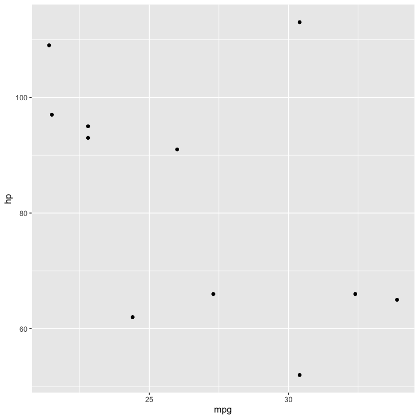

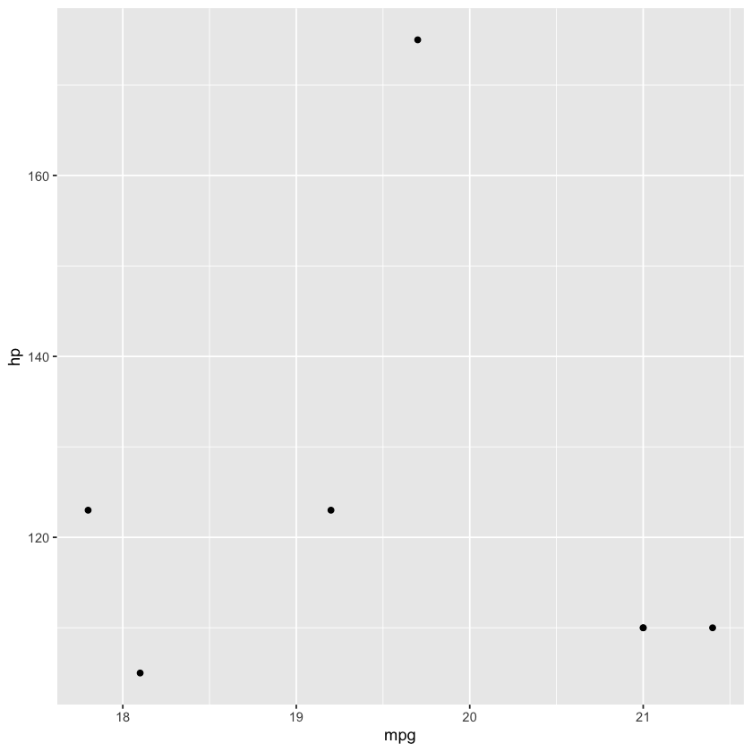

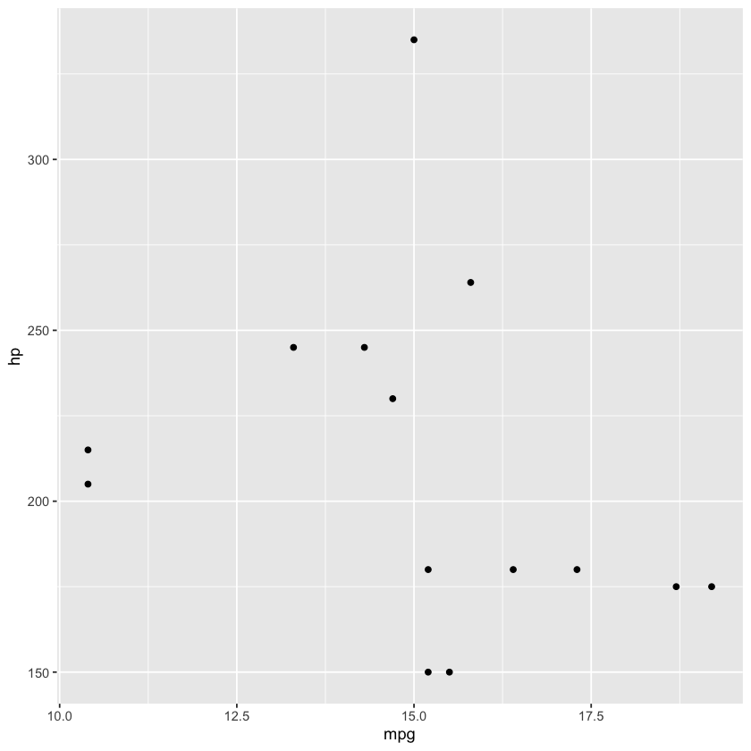

```r
ggplot(mtcars %>% filter(cyl==4),aes(x=mpg,y=hp)) +geom_point()
ggplot(mtcars %>% filter(cyl==6),aes(x=mpg,y=hp)) +geom_point()
ggplot(mtcars %>% filter(cyl==8),aes(x=mpg,y=hp)) +geom_point()
```

## DOs

Make effective use of colour, shape to combine graphs

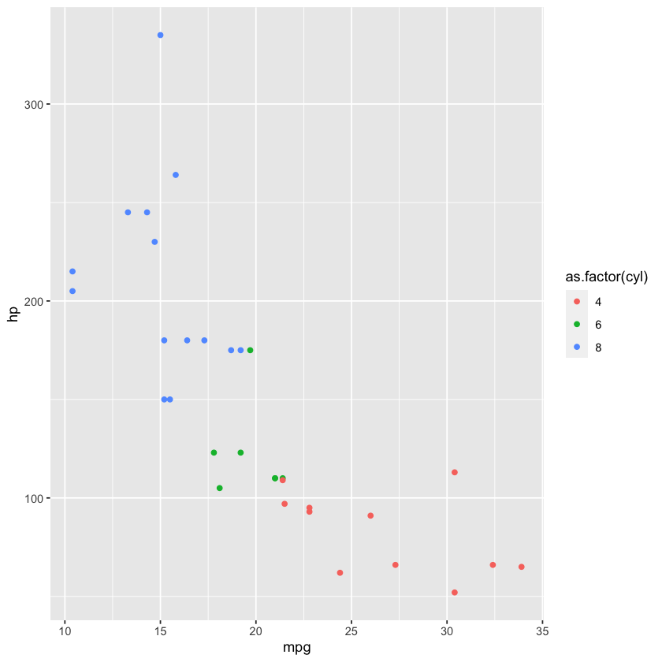

```r
ggplot(mtcars ,aes(x=mpg,y=hp, color=as.factor(cyl))) +geom_point()
```

## DON'Ts

Include a large chunk of code without any explanation, comments, docstring

A data.frame: 6 × 11

|  | mpg <dbl> | cyl <dbl> | disp <dbl> | hp <dbl> | drat <dbl> | wt <dbl> | qsec <dbl> | vs <dbl> | am <dbl> | gear <dbl> | carb <dbl> |
| --- | --- | --- | --- | --- | --- | --- | --- | --- | --- | --- | --- |
| Mazda RX4 | 21.0 | 6 | 160 | 110 | 3.90 | 2.620 | 16.46 | 0 | 1 | 4 | 4 |
| Mazda RX4 Wag | 21.0 | 6 | 160 | 110 | 3.90 | 2.875 | 17.02 | 0 | 1 | 4 | 4 |
| Datsun 710 | 22.8 | 4 | 108 | 93 | 3.85 | 2.320 | 18.61 | 1 | 1 | 4 | 1 |
| Hornet 4 Drive | 21.4 | 6 | 258 | 110 | 3.08 | 3.215 | 19.44 | 1 | 0 | 3 | 1 |
| Hornet Sportabout | 18.7 | 8 | 360 | 175 | 3.15 | 3.440 | 17.02 | 0 | 0 | 3 | 2 |
| Valiant | 18.1 | 6 | 225 | 105 | 2.76 | 3.460 | 20.22 | 1 | 0 | 3 | 1 |

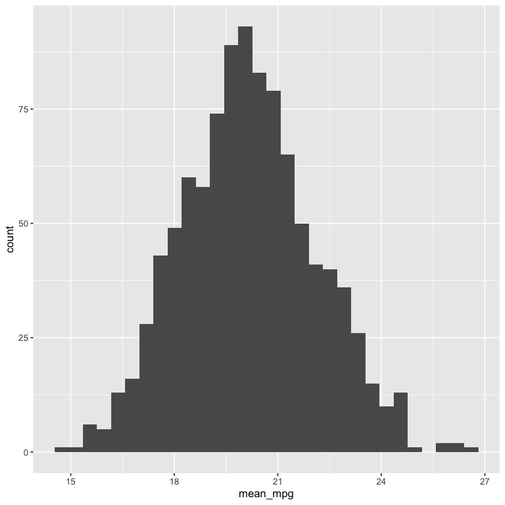

```r
head(mtcars)
mtcars_grouped <- mtcars  %>% group_by(am)  %>% summarise(mean(mpg))
library(infer)
mtcars_sim <- rep_sample_n(mtcars, size=10,reps=1000, replace=TRUE)
mtcars_sim_grp <- mtcars_sim %>% group_by(replicate)  %>% summarise(mean_mpg = mean(mpg))
ggplot(mtcars_sim_grp,aes(x=mean_mpg)) + geom_histogram()
```